# ME414 - Estatística para Experimentalistas

## Distribuição amostral

## Exemplo: Eleições para a prefeitura

- Quero saber se o candidato \(A\) vai ganhar as eleições para prefeito.
- Cidade com \(N\) pessoas.
- Posso esperar o resultado das eleições para saber, ou seja, teríamos a resposta de todas as pessoas da cidade.
- Posso usar uma amostra para estimar a proporção de votos para \(A\).
- Quão boa é a estimativa? É precisa?
- Posso pensar no problema de duas formas: Modo 1 e Modo 2.

## Modo 1

- Cidade com \(N\) pessoas.
- \(X_i = 1\) se a pessoa \(i\) vota em \(A\)
- \(X_i=0\) se a pessoa \(i\) não vota em \(A\).
- \(\mathbf{X}=(X_1,X_2,\ldots,X_N)\): resposta de toda a população (temos no dia da eleição).
- Média populacional: \[p=\frac{1}{N}\sum_{i=1}^N X_i\]

## Modo 1

- Variância populacional:

\[\begin{eqnarray} \sigma^2&=&\frac{1}{N}\sum_{i=1}^N(X_i-p)^2\\ &=&\frac{1}{N}\sum_{i=1}^N(X_i^2-2pX_i+p^2)\\ &=&\frac{\sum_{i=1}^N X_i^2-2p\sum_{i=1}^N X_i+\sum_{i=1}^N p^2}{N}\\ &=&\frac{\sum_{i=1}^N X_i-2p\sum_{i=1}^N X_i+\sum_{i=1}^N p^2}{N}\\ &=&\frac{Np-2pNp+Np^2}{N}=p(1-p) \end{eqnarray}\]

## Modo 1

- \(p\) = proporção de pessoas que votam em \(A\) na cidade
- \(\sigma^2=p(1-p)\) é a variância da população.
- Até o dia da eleição, não sabemos \(p\).
- Coletamos uma amostra aleatória de tamanho \(n\) para uma pesquisa eleitoral.
- \(\hat{p}\): proporção de pessoas que votam em \(A\) na amostra.
- Quão boa é a estimativa? É precisa?
- Se outra pessoa tambem coleta uma amostra aleatória de tamanho \(n\) e calcula \(\hat{p}\) teremos o mesmo valor?

## Modo 1 - Exemplo \(N=5\) e \(n=2\)

\[\mathbf{X}=(X_1,X_2,\ldots,X_5)=(1,0,1,0,1)\]

\[p=\frac{\sum_{i=1}^5X_i}{5}=\frac{3}{5}=0.6\]

\[\begin{eqnarray} \sigma^2&=&\frac{1}{5}\sum_{i=1}^N(X_i-p)^2\\ &=&\frac{3\times(1-0.6)^2+2\times(0-0.6)^2}{5}\\ &=&0.24\\ &=&p(1-p) \end{eqnarray}\]

## Modo 1 - Exemplo \(N=5\) e \(n=2\)

Gráfico de barras (proporção) dos dados populacionais:

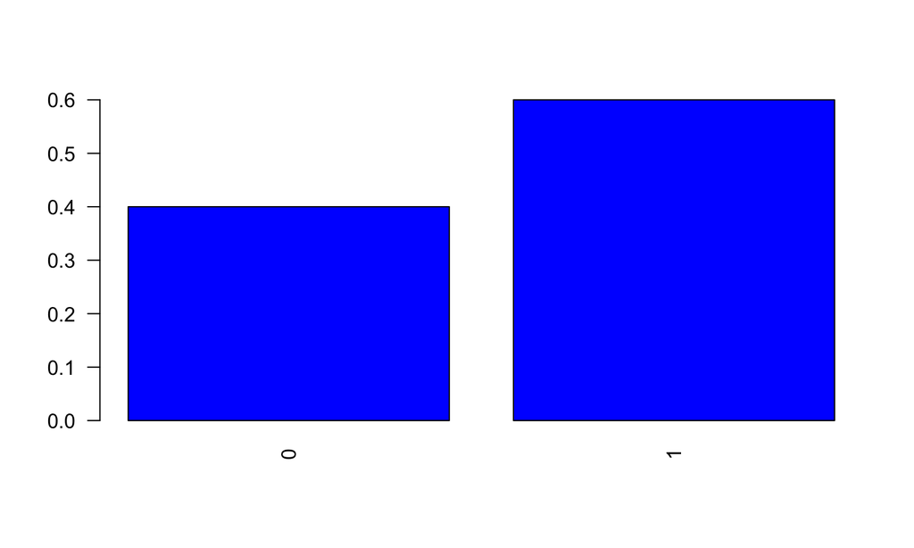

## Modo 1 - Exemplo \(N=5\) e \(n=2\)

| Pessoa amostrada 1 | Pessoa amostrada 2 | \(\hat{p}\) |
| --- | --- | --- |
| 1 | 1 | 1.0 |
| 2 | 1 | 0.5 |
| 3 | 1 | 1.0 |
| 4 | 1 | 0.5 |
| 5 | 1 | 1.0 |
| 1 | 2 | 0.5 |
| 2 | 2 | 0.0 |
| 3 | 2 | 0.5 |
| 4 | 2 | 0.0 |
| 5 | 2 | 0.5 |
| 1 | 3 | 1.0 |
| 2 | 3 | 0.5 |
| 3 | 3 | 1.0 |
| 4 | 3 | 0.5 |
| 5 | 3 | 1.0 |
| 1 | 4 | 0.5 |
| 2 | 4 | 0.0 |
| 3 | 4 | 0.5 |
| 4 | 4 | 0.0 |
| 5 | 4 | 0.5 |
| 1 | 5 | 1.0 |
| 2 | 5 | 0.5 |
| 3 | 5 | 1.0 |
| 4 | 5 | 0.5 |
| 5 | 5 | 1.0 |

## Modo 1 - Exemplo \(N=5\) e \(n=2\)

Distribuição **amostral** de \(\hat{p}\):

| \(x\) | \(P(\hat{p}=x)\) |
| --- | --- |
| 0 | 0.16 |
| 0.5 | 0.48 |
| 1 | 0.36 |

\[\begin{eqnarray} E(\hat{p})&=&0\times 0.16 + 0.5\times 0.48 + 1\times 0.36 = 0.6 = p\\ Var(\hat{p})&=&E[(\hat{p}-p)^2]\\ &=&0.16\times(0-0.6)^2 + 0.48\times(0.5-0.6)^2 + 0.36\times (1-0.6)^2\\ &=&0.12=\frac{p(1-p)}{n} \end{eqnarray}\]

## Modo 1 - Exemplo \(N=5\) e \(n=2\)

Distribuição amostral de \(\hat{p}\):

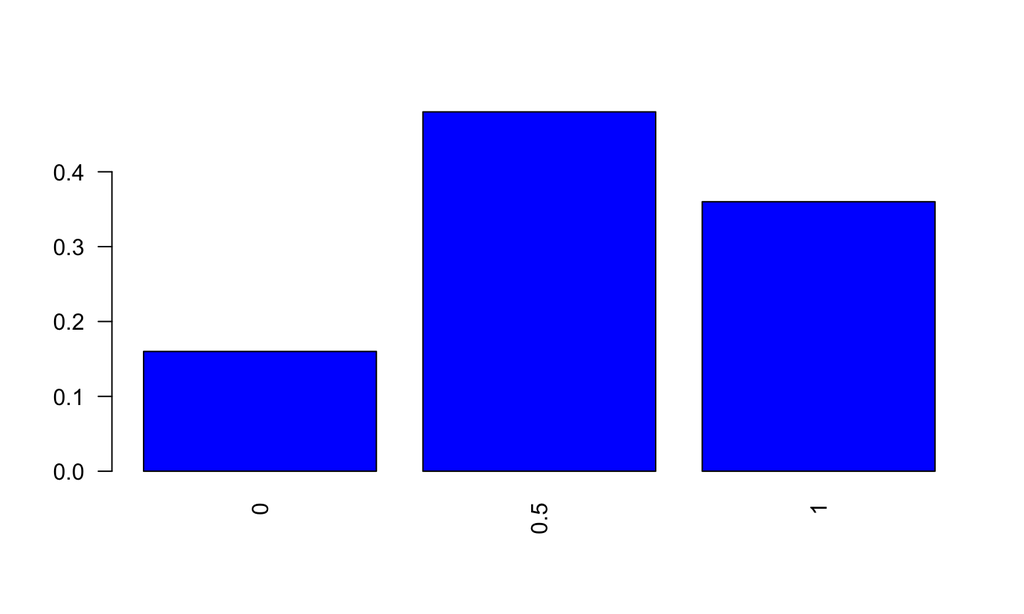

## Modo 1 - Exemplo \(N=5\) e \(n=3\)

| Pessoa amostrada 1 | Pessoa amostrada 2 | Pessoa amostrada 3 | \(\hat{p}\) |
| --- | --- | --- | --- |
| 1 | 1 | 1 | 1.000 |
| 2 | 1 | 1 | 0.667 |
| 3 | 1 | 1 | 1.000 |
| 4 | 1 | 1 | 0.667 |
| 5 | 1 | 1 | 1.000 |
| 1 | 2 | 1 | 0.667 |
| 2 | 2 | 1 | 0.333 |
| 3 | 2 | 1 | 0.667 |
| 4 | 2 | 1 | 0.333 |
| 5 | 2 | 1 | 0.667 |
| 1 | 3 | 1 | 1.000 |
| 2 | 3 | 1 | 0.667 |
| 3 | 3 | 1 | 1.000 |
| 4 | 3 | 1 | 0.667 |
| 5 | 3 | 1 | 1.000 |
| 1 | 4 | 1 | 0.667 |
| 2 | 4 | 1 | 0.333 |
| 3 | 4 | 1 | 0.667 |
| 4 | 4 | 1 | 0.333 |
| 5 | 4 | 1 | 0.667 |
| 1 | 5 | 1 | 1.000 |
| 2 | 5 | 1 | 0.667 |
| 3 | 5 | 1 | 1.000 |
| 4 | 5 | 1 | 0.667 |
| 5 | 5 | 1 | 1.000 |
| 1 | 1 | 2 | 0.667 |
| 2 | 1 | 2 | 0.333 |
| 3 | 1 | 2 | 0.667 |
| 4 | 1 | 2 | 0.333 |
| 5 | 1 | 2 | 0.667 |

[output cut: 95 more lines]

## Modo 1 - Exemplo \(N=5\) e \(n=3\)

Distribuição **amostral** de \(\hat{p}\):

| \(x\) | \(P(\hat{p}=x)\) |
| --- | --- |
| 0 | 0.064 |
| 0.333 | 0.288 |
| 0.667 | 0.432 |
| 1 | 0.216 |

\[\begin{eqnarray} E(\hat{p})&=&0\times 0.064 + 0.333\times 0.288 + 0.667\times 0.432 + 1\times 0.216\\ &=& 0.6 = p\\ Var(\hat{p})&=&E[(\hat{p}-p)^2]\\ &=&0.08=\frac{p(1-p)}{n} \end{eqnarray}\]

## Modo 1 - Exemplo \(N=5\) e \(n=3\)

Distribuição amostral de \(\hat{p}\):

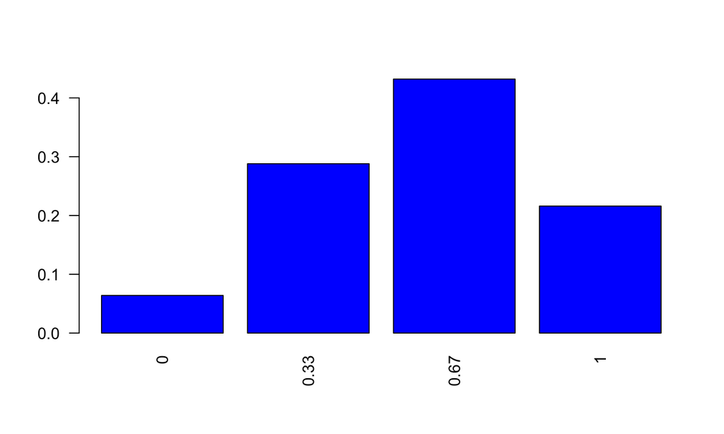

## Modo 1

- Amostra aleatória de tamanho \(n\):
- \(\hat{p}\) é v.a.
- \(E(\hat{p})=p\)
- \(Var(\hat{p})=\frac{p(1-p)}{n}\).

## Modo 1 - Exemplo \(N=1000000\) e \(n=100\)

Distribuição **amostral** de \(\hat{p}\):

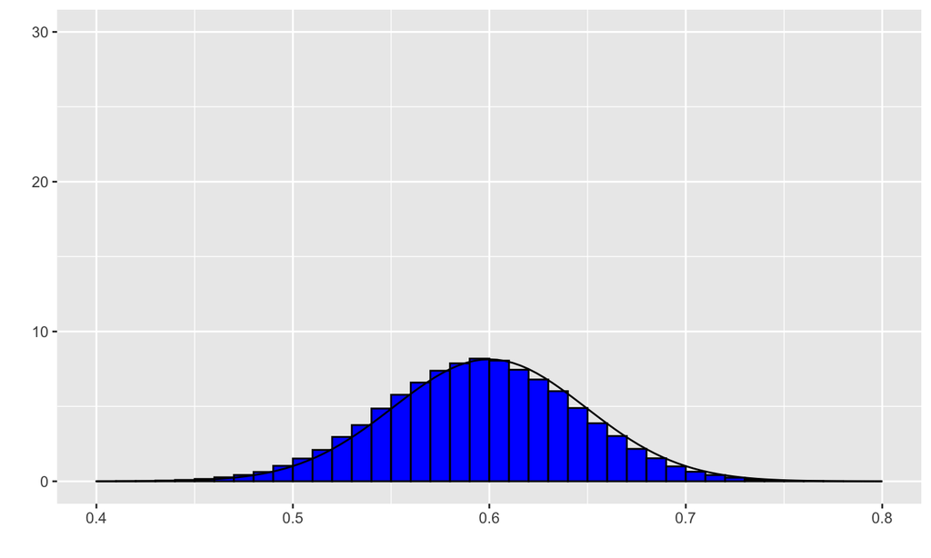

## Modo 1 - Exemplo \(N=1000000\) e \(n=1000\)

Distribuição **amostral** de \(\hat{p}\):

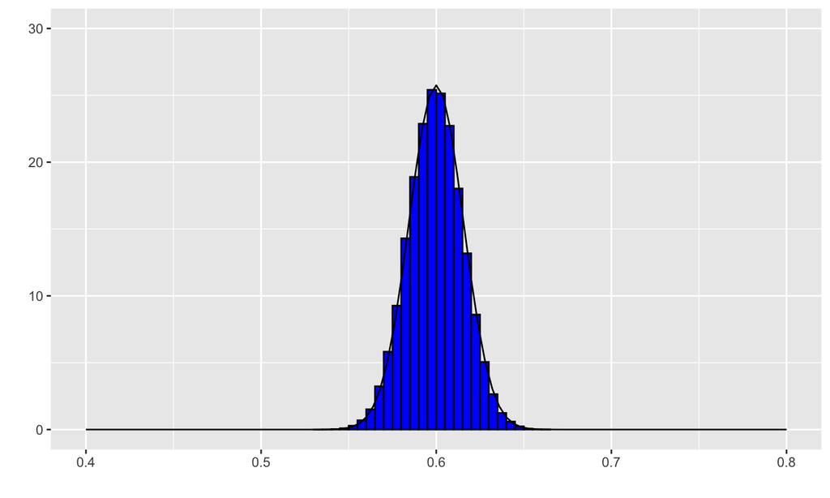

## Modo 2

Suponha que a resposta de uma pessoa da cidade sobre se vota ou não no candidato \(A\) possa ser representada por uma v.a. \(X\) que assume o valor \(1\) com probabilidade \(p\) ou \(0\) com probabilidade \(1-p\). \(X\sim Bernoulli(p)\).

\(\begin{aligned} \mathbb E(X) &= 1 \times P(X=1) + 0 \times P(X=0) \\ &= 1\times p + 0\times (1-p) = p \end{aligned}\)

\(\begin{aligned} \sigma^2 &= Var(X) = \mathbb E[(X - \mu)^2] \\ &= (1-p)^2 \times P(X=1) + (0 - p)^2 \times P(X=0) \\ &=p(1-p)^2+(1-p)p^2\\ &= p(1-p) \end{aligned}\)

## Modo 2

Distribuição da variável \(X\):

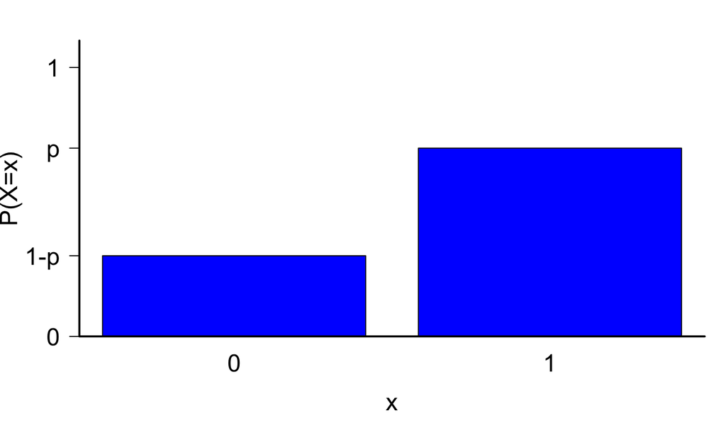

## Modo 2 - Exemplo \(n=2\)

> Todas as combinações possíveis de valores para o primeiro e para o segundo elemento amostrados segundo o plano \(AAS_c\) com \(n=2\) são:

| Possibilidades | \((X_1 = 1, X_2 = 1)\) | \((X_1 = 1, X_2 = 0)\) | \((X_1 = 0, X_2 = 1)\) | \((X_1=0,X_2=0)\) |
| --- | --- | --- | --- | --- |
| \(\hat{p}=\frac{1}{n}\sum_{i=1}^nX_i\) | 1 | 0.5 | 0.5 | 0 |
| \(P(X_1 = i, X_2 = j)\) | \(p^2\) | \(p(1-p)\) | \((1-p)p\) | \((1-p)^2\) |

> \(\displaystyle \mathbb E(\hat{p}) = 1 \times p^2 + 0.5 \times p(1-p) + 0.5 \times (1-p)p + 0\times (1-p)^2= p\)

> \(\begin{aligned} Var(\hat{p}) &= \mathbb E[(\hat{p} - p)^2 ] \\ &= (1 - p)^2 \times p^2 + (0.5 - p)^2 p(1-p) + (0.5 - p)^2 (1-p)p + (0 - p)^2 (1-p)^2 = \frac{p(1-p)}{2} \end{aligned}\)

> Note que: \(\displaystyle \mathbb E(\hat{p}) = p = \mathbb E(X)\) e \(\displaystyle Var(\hat{p}) = \frac{\sigma^2}{n} = \frac{Var(X)}{n}\).

## Resultado

Seja \(X\) uma v.a. com média \(\mu\) e variância \(\sigma^{2}\) e \(X_{1}, \ldots, X_{n}\) uma amostra aleatória simples de \(X\). A média amostral \[\bar X_n = \frac{X_1 + \ldots + X_n}{n}\] tem as seguintes propriedades:

> \[\mathbb E (\bar X_n) = \mu \qquad \mbox{e} \qquad Var(\bar X_n) = \frac{\sigma^2}{n}.\]

Ou seja, embora \(\mu\) seja desconhecido, sabemos que o valor esperado da média amostral é \(\mu\).

Além disso, conforme o tamanho amostral aumenta, a imprecisão da média amostral para estimar \(\mu\) fica cada vez menor, pois \(Var(\bar X) = \sigma^2/n\).

(propriedade de linearidade da esperança e da variância, esta última em caso de independência)

## Teorema do Limite Central

## Teorema do Limite Central

Usando o resultado enunciado anteriormente, temos a esperança e a variância da média amostral \(\bar X\): \(\mathbb E(\bar X) = \mu\) e \(Var(\bar X) = \frac{\sigma^2}{n}\).

> No entanto, para conhecermos a distribuição de probabilidade de \(\bar X\), como foi feito no exemplo anterior, é preciso conhecer todos os valores possíveis de \(X\) e suas respectivas probabilidades.

> Mas, se conhecermos tudo isso, não precisamos fazer amostragem nem inferência: saberemos tudo o que desejarmos daquela população!

> O exemplo anterior foi um caso hipotético apenas para demonstrar como a média amostral \(\bar X\) se comporta quando realizamos a amostragem.

> Na prática, não teremos informações suficientes para de fato descrevermos a distribuição exata de \(\bar X\).

## Leituras

- [Ross](http://www.sciencedirect.com/science/article/pii/B9780123743886000077): capítulo 7.
- [OpenIntro](https://www.openintro.org/stat/textbook.php): seção 4.1.
- Magalhães: capítulo 7.

Slides produzidos pelos professores:

- Samara Kiihl
- Tatiana Benaglia
- Benilton Carvalho